## INTRODUCTION AND ASSIGNMENT

The basic goal of this assignment is to explore the NOAA Storm Database and answer some basic questions about severe weather events. Storms and other severe weather events can cause both public health and economic problems for communities and municipalities.

Many severe events can result in fatalities, injuries, and property damage, and preventing such outcomes to the extent possible is a key concern. This project involves exploring the U.S. National Oceanic and Atmospheric Administration’s (NOAA) storm database. The NOAA Storm database tracks characteristics of major storms and weather events in the United States, including when and where they occur, as well as estimates of any fatalities, injuries, and property damage.

Each of the two questions has a DATA PROCESSING and RESULTS section. There is also a RESULTS SUMMARY section at the end.

## SYNPOSIS

Using the U.S. National Oceanic and Atmospheric Administration’s (NOAA) Storm database, analysis of the data from 1950 to November 2011 concludes: (1) Tornados cause the most harm to population as measured by fatalities and injuries. (2) Floods cause the most economic damage to property, and Drought causes the most economic damage to crops.  
The NOAA storm database records specific data (date, location, weather event type, estimated fatalities & injuries, estimated damage) of major storms and weather events in the United States. The analysis of the data was use to identify the weather events causing the most harm (fatalities and injuries) to the population and/or the greatest economic consequences (damages).

##DATA PROCESSING for Question 1: What weather events causing the most harm to population (health)? ##Step 1 Get Data Get the raw data file in the form of a comma-separated-value file compressed via the bzip2 algorithm to reduce its size. You can download the file from the course web site for Reproducible Research Project 2 Storm Data. The function Bunzip is used to unzip the raw data file and save it to the working directory in csv format. Use the dim function to get size information on how the large dataset.

```r
library(data.table)
```

```r
library(ggplot2)
library(scales)
library(lubridate)
library(dplyr)
library(R.utils)
library(rmarkdown)
library(knitr)

if(!file.exists("RawStormData.csv"))
{bunzip2("repdata_data_StormData.csv.bz2","RawStormData.csv",remove=F)}

StormData <- read.csv("RawStormData.csv", header=TRUE,sep=",")
dim(StormData)
```

```
## [1] 902297     37
```

## Step 2 Get only the data needed for analysis

Using the information provided in the NOAA website https://d396qusza40orc.cloudfront.net/repdata%2Fpeer2_doc%2Fpd01016005curr.pdf determine which fields are needed for the analysis. The Data needed:  
(1) Event Types (EVTYPE) (2) FATALITIES (column 23) (3) INJURIES (column 24) (4) Property Damage (PROPDMG - column 25) (5) Property Damage Exponet (PROPDAMAGE - column 26) (6) Crop Damage (CROPDMG - column 27) (7) Crop Damage Exponet (CROPDAMAGE - column 28)

```r
StormDataAnalyzed <- StormData[ , c(8, 23:28)]
rm(StormData)
names(StormDataAnalyzed)
```

```
## [1] "EVTYPE"     "FATALITIES" "INJURIES"   "PROPDMG"    "PROPDMGEXP"
## [6] "CROPDMG"    "CROPDMGEXP"
```

```r
summary(StormDataAnalyzed)
```

```
##                EVTYPE         FATALITIES          INJURIES
##  HAIL             :288661   Min.   :  0.0000   Min.   :   0.0000
##  TSTM WIND        :219940   1st Qu.:  0.0000   1st Qu.:   0.0000
##  THUNDERSTORM WIND: 82563   Median :  0.0000   Median :   0.0000
##  TORNADO          : 60652   Mean   :  0.0168   Mean   :   0.1557
##  FLASH FLOOD      : 54277   3rd Qu.:  0.0000   3rd Qu.:   0.0000
##  FLOOD            : 25326   Max.   :583.0000   Max.   :1700.0000
##  (Other)          :170878
##     PROPDMG          PROPDMGEXP        CROPDMG          CROPDMGEXP
##  Min.   :   0.00          :465934   Min.   :  0.000          :618413
##  1st Qu.:   0.00   K      :424665   1st Qu.:  0.000   K      :281832
##  Median :   0.00   M      : 11330   Median :  0.000   M      :  1994
##  Mean   :  12.06   0      :   216   Mean   :  1.527   k      :    21
##  3rd Qu.:   0.50   B      :    40   3rd Qu.:  0.000   0      :    19
##  Max.   :5000.00   5      :    28   Max.   :990.000   B      :     9
##                    (Other):    84                     (Other):     9
```

## Step 3 Analyze the data to determine the weather events causing the most harm (fatalities and injuries)

Get the top 10 weather events that inflict the most harm on the population in the form of FATALITIES and INJURIES. Analyze the top 10 of each before plotting to determine the best way to present the data. The “top 10” is an arbitrary number selected, but for reproducibility it is documented as what was selected.

```r
FatalitiesStormData <- aggregate(FATALITIES~EVTYPE, data=StormDataAnalyzed, sum, na.rm = TRUE)
FatalitiesStormData <- arrange(FatalitiesStormData, desc(FATALITIES))
TopFatalitiesStormData <- FatalitiesStormData[1:10, ]
TopFatalitiesStormData
```

```
##            EVTYPE FATALITIES
## 1         TORNADO       5633
## 2  EXCESSIVE HEAT       1903
## 3     FLASH FLOOD        978
## 4            HEAT        937
## 5       LIGHTNING        816
## 6       TSTM WIND        504
## 7           FLOOD        470
## 8     RIP CURRENT        368
## 9       HIGH WIND        248
## 10      AVALANCHE        224
```

```r
InjuriesStormData <- aggregate(INJURIES~EVTYPE, data=StormDataAnalyzed, sum, na.rm = TRUE)
InjuriesStormData <- arrange(InjuriesStormData, desc(INJURIES))
TOPInjuriesStormData <- InjuriesStormData[1:10, ]
TOPInjuriesStormData
```

```
##               EVTYPE INJURIES
## 1            TORNADO    91346
## 2          TSTM WIND     6957
## 3              FLOOD     6789
## 4     EXCESSIVE HEAT     6525
## 5          LIGHTNING     5230
## 6               HEAT     2100
## 7          ICE STORM     1975
## 8        FLASH FLOOD     1777
## 9  THUNDERSTORM WIND     1488
## 10              HAIL     1361
```

## Answer to Question #1 is Tornados

## Step 4 Summary analysis of weather events causing the most harm (fatalities and injuries)

Tornadoes cause the most fatalities AND the most injuries, and plotting them both on a single bar chart displays the data concisely.

```r
HarmfulStormData <- aggregate(cbind(FATALITIES,INJURIES)~EVTYPE, data=StormDataAnalyzed, sum, na.rm = TRUE)
TopHarmfulStormData <- arrange(HarmfulStormData, desc(FATALITIES+INJURIES))
TopHarmfulStormData <- TopHarmfulStormData[1:10, ]
TopHarmfulStormData
```

```
##               EVTYPE FATALITIES INJURIES
## 1            TORNADO       5633    91346
## 2     EXCESSIVE HEAT       1903     6525
## 3          TSTM WIND        504     6957
## 4              FLOOD        470     6789
## 5          LIGHTNING        816     5230
## 6               HEAT        937     2100
## 7        FLASH FLOOD        978     1777
## 8          ICE STORM         89     1975
## 9  THUNDERSTORM WIND        133     1488
## 10      WINTER STORM        206     1321
```

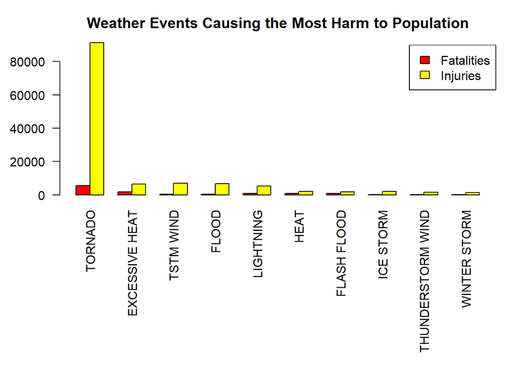

```r
HarmfulEVTYPE <- TopHarmfulStormData$EVTYPE
TopHarmfulStormData2 <- as.matrix(t(TopHarmfulStormData[,-1]))
colnames(TopHarmfulStormData2) <- HarmfulEVTYPE

par(mar=c(12,4,3,2))
barplot(TopHarmfulStormData2, col = c("Red", "Yellow"), beside = T, ylim = c(0,90000), las = 2,  main = "Weather Events Causing the Most Harm to Population")
legend("topright", c("Fatalities", "Injuries"), fill = c("Red", "Yellow"), bty = "HarmfulEVTYPE")
```

## DATA PROCESSING for Question 2: What weather events have the most economic impact (cost)?

## Step 1 Get Data and cleanup exponent data

Use the same dataset defined in the “Question 1 Step 1 - StormDataAnalyzed”, and analyze the Crop and property damage exponent data to determine significance and population of data by exponent. Per page 12 fo the NOAA Storm Database documentation: “values are in Estimates should be rounded to three significant digits, followed by an alphabetical character signifying the magnitude of the number, i.e., 1.55B for $1,550,000,000. Alphabetical characters used to signify magnitude include “K” for thousands, “M” for millions, and “B” for billions."  
The exponent values used in the analysis are: (1) K or k = thousands (1000) (2) M or m = millions (1000000) (3) B or b = billions (1000000000) (4) blank = 1 (5) all others are small counts and set to zero and not included in cost analysis Exponent values CROPDMGEXP2 and PROPDMGEXP2 are set zero by default.

```r
unique(StormDataAnalyzed$CROPDMGEXP)
```

```
## [1]   M K m B ? 0 k 2
## Levels:  ? 0 2 B k K m M
```

```r
table(StormDataAnalyzed$CROPDMGEXP)
```

```
##
##             ?      0      2      B      k      K      m      M
## 618413      7     19      1      9     21 281832      1   1994
```

```r
unique(StormDataAnalyzed$PROPDMGEXP)
```

```
##  [1] K M   B m + 0 5 6 ? 4 2 3 h 7 H - 1 8
## Levels:  - ? + 0 1 2 3 4 5 6 7 8 B h H K m M
```

```r
table(StormDataAnalyzed$PROPDMGEXP)
```

```
##
##             -      ?      +      0      1      2      3      4      5      6
## 465934      1      8      5    216     25     13      4      4     28      4
##      7      8      B      h      H      K      m      M
##      5      1     40      1      6 424665      7  11330
```

```r
StormDataAnalyzed$CROPDMGEXP2 <- 0

StormDataAnalyzed$CROPDMGEXP2[StormDataAnalyzed$CROPDMGEXP == ""] <- 1
StormDataAnalyzed$CROPDMGEXP2[StormDataAnalyzed$CROPDMGEXP == "k"] <- 1000
StormDataAnalyzed$CROPDMGEXP2[StormDataAnalyzed$CROPDMGEXP == "K"] <- 1000
StormDataAnalyzed$CROPDMGEXP2[StormDataAnalyzed$CROPDMGEXP == "m"] <- 1000000
StormDataAnalyzed$CROPDMGEXP2[StormDataAnalyzed$CROPDMGEXP == "M"] <- 1000000
StormDataAnalyzed$CROPDMGEXP2[StormDataAnalyzed$CROPDMGEXP == "b"] <- 1000000000
StormDataAnalyzed$CROPDMGEXP2[StormDataAnalyzed$CROPDMGEXP == "B"] <- 1000000000

table(StormDataAnalyzed$CROPDMGEXP2)
```

```
##
##      0      1   1000  1e+06  1e+09
##     27 618413 281853   1995      9
```

```r
StormDataAnalyzed$PROPDMGEXP2 <- 0

StormDataAnalyzed$PROPDMGEXP2[StormDataAnalyzed$PROPDMGEXP == ""] <- 1
StormDataAnalyzed$PROPDMGEXP2[StormDataAnalyzed$PROPDMGEXP == "k"] <- 1000
StormDataAnalyzed$PROPDMGEXP2[StormDataAnalyzed$PROPDMGEXP == "K"] <- 1000
StormDataAnalyzed$PROPDMGEXP2[StormDataAnalyzed$PROPDMGEXP == "m"] <- 1000000
StormDataAnalyzed$PROPDMGEXP2[StormDataAnalyzed$PROPDMGEXP == "M"] <- 1000000
StormDataAnalyzed$PROPDMGEXP2[StormDataAnalyzed$PROPDMGEXP == "b"] <- 1000000000
StormDataAnalyzed$PROPDMGEXP2[StormDataAnalyzed$PROPDMGEXP == "B"] <- 1000000000

table(StormDataAnalyzed$PROPDMGEXP2)
```

```
##
##      0      1   1000  1e+06  1e+09
##    321 465934 424665  11337     40
```

## Step 2 Calculate the Property and Crop damage cost

```r
StormDataAnalyzed$PROPDMGCost <- StormDataAnalyzed$PROPDMG * StormDataAnalyzed$PROPDMGEXP2
StormDataAnalyzed$CROPDMGCost <- StormDataAnalyzed$CROPDMG * StormDataAnalyzed$CROPDMGEXP2
```

## Step 3 Analyze the data to determine the weather events with the most economic impact (cost)

Get the top 10 weather events that cost the most for property and crops. Analyze the top 10 of each before plotting to determine the best way to present the data. The “top 10” is an arbitrary number selected, but for reproducibility it is documented as what was selected.

```r
CostPropDMGStormData <- aggregate(PROPDMGCost~EVTYPE, data=StormDataAnalyzed, sum, na.rm = TRUE)
CostPropDMGStormData <- arrange(CostPropDMGStormData, desc(PROPDMGCost))
TopCostPropDMGStormData <- CostPropDMGStormData[1:10, ]
TopCostPropDMGStormData
```

```
##               EVTYPE  PROPDMGCost
## 1              FLOOD 144657709807
## 2  HURRICANE/TYPHOON  69305840000
## 3            TORNADO  56937160483
## 4        STORM SURGE  43323536000
## 5        FLASH FLOOD  16140811717
## 6               HAIL  15732266777
## 7          HURRICANE  11868319010
## 8     TROPICAL STORM   7703890550
## 9       WINTER STORM   6688497250
## 10         HIGH WIND   5270046260
```

```r
CostCropDMGStormData <- aggregate(CROPDMGCost~EVTYPE, data=StormDataAnalyzed, sum, na.rm = TRUE)
CostCropDMGStormData <- arrange(CostCropDMGStormData, desc(CROPDMGCost))
TopCostCropDMGStormData <- CostCropDMGStormData[1:10, ]
TopCostCropDMGStormData
```

```
##               EVTYPE CROPDMGCost
## 1            DROUGHT 13972566000
## 2              FLOOD  5661968450
## 3        RIVER FLOOD  5029459000
## 4          ICE STORM  5022113500
## 5               HAIL  3025954453
## 6          HURRICANE  2741910000
## 7  HURRICANE/TYPHOON  2607872800
## 8        FLASH FLOOD  1421317100
## 9       EXTREME COLD  1292973000
## 10      FROST/FREEZE  1094086000
```

## Answer to Question #2 is Floods for property and Drought for crops.

## Step 4 Summary analysis of weather events with the highest economic impact (cost)

Floods have the highest cost for property, and Drought has the highest cost for crops. Therefore, plotting them on seperate charts displays the data best.

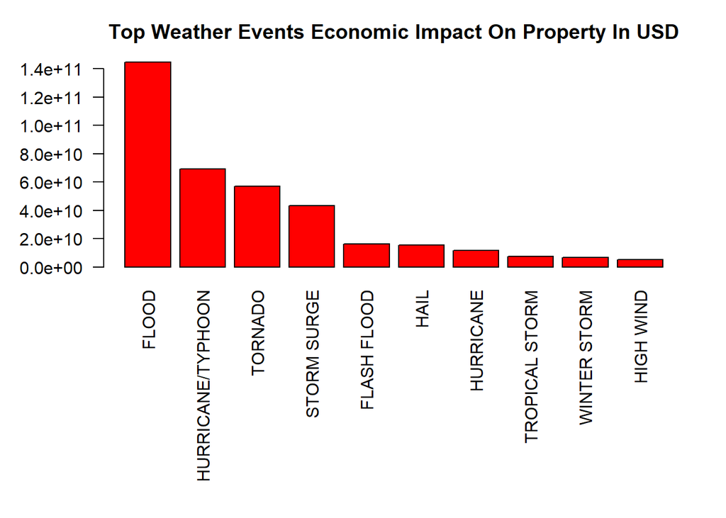

```r
par(mar=c(12,5,3,2))
barplot(TopCostPropDMGStormData$PROPDMGCost,names.arg=TopCostPropDMGStormData$EVTYPE,las=2,col="Red", main="Top Weather Events Economic Impact On Property In USD")
```

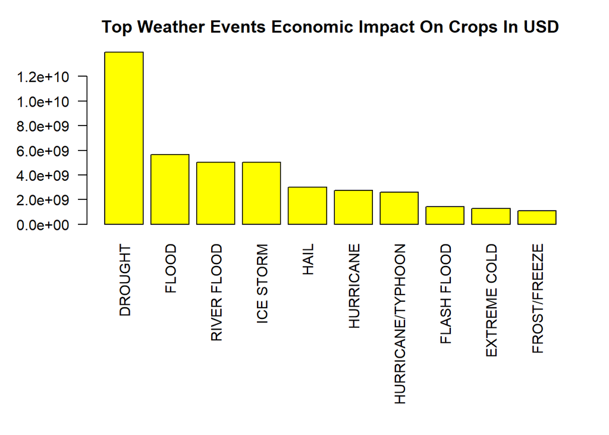

```r
par(mar=c(12,5,3,2))
barplot(TopCostCropDMGStormData$CROPDMGCost,names.arg=TopCostCropDMGStormData$EVTYPE,las=2,col="Yellow", main="Top Weather Events Economic Impact On Crops In USD")
```

## RESULTS SUMMARY

Question (1) Tornados cause the most harm to population as measured by fatalities and injuries.

Question (2) Floods cause the most economic damage to property, and Drought causes the most economic damage to crops.